# I. Data Exploration for Project 4 ML

**(Segment the Customer Base of an e-commerce Website)**

## Contents

1. Merging all datasets into one
   1. Merging order_items_data with products_data on product_id
   2. Merging order_items_data with sellers_data on seller_id
   3. Merging orders_data with customers_data on customer_id
   4. Merging orders_data with order_items_data
      1. Preparation of order_items dataset before the merge
      2. Merging orders_data with order_items_agg on order_id
   5. Merging orders_data with order_reviews_data
      1. Preparation of order_reviews dataset before the merge
      2. Merging orders_data with order_reviews_agg on order_id
   6. Merging orders_data with order_payments_data
      1. Preparation of order_reviews dataset before the merge
      2. Merging orders_data with order_payments_agg on order_id
   7. Ckecking the final dataset
2. Selection of data and missing values treatment
   1. Selection of delivered orders
   2. Cleaning the data from wrong value and outlier
      1. Cleaning the data from negative values
      2. Cleaning the data from outliers in all numerical columns
   3. Missing value treatment
      1. Treatment of tot_price, tot_freight_value, and tot_payment_value
      2. Treatment of order_approved_at, order_delivered_carrier_date,  
         and order_delivered_customer_date
      3. Final check for missing values
3. Feature Engineering
4. Analysis
   1. Univariate analysis
   2. Bivariate analysis
   3. Multivariate analysis
      1. Standardize the data
      2. Performing dimension reduction using t-SNE
         1. RFM features
         2. RFM + review score features
         3. RFM + review score + delivery time features
5. Extracting the datasets

```python
import numpy as np
import pandas as pd
import matplotlib.pyplot as plt
import seaborn as sns
import scipy.stats as st
import missingno as msno

from sklearn.preprocessing import StandardScaler
from sklearn.decomposition import PCA
from sklearn.manifold import TSNE

from collections import Counter

import math

sns.set()
```

```python
customers_data = pd.read_csv('data/olist_customers_dataset.csv')
geolocation_data = pd.read_csv('data/olist_geolocation_dataset.csv')
order_items_data = pd.read_csv('data/olist_order_items_dataset.csv')
order_payments_data = pd.read_csv('data/olist_order_payments_dataset.csv')
order_reviews_data = pd.read_csv('data/olist_order_reviews_dataset.csv')
orders_data = pd.read_csv('data/olist_orders_dataset.csv')
products_data = pd.read_csv('data/olist_products_dataset.csv')
sellers_data = pd.read_csv('data/olist_sellers_dataset.csv')
```

```python
# To display all columns when needed
pd.set_option('display.max_columns', None)


# Function to add infos about the type and null values to .describe function
def df_description(df):
    # General description
    description = df.describe(include='all', datetime_is_numeric=True)

    # Types and content of the columns
    description_type = pd.DataFrame(df.dtypes, columns=['type']).T
    number_null = (df.shape[0] - description.loc['count'].T)
    percent_null = (df.shape[0] - description.loc['count'].T)*100/df.shape[0]
    description_null = pd.DataFrame([number_null, percent_null],
                                    index=['number null', 'percentage null'])

    # Concatenate general, type and null stats
    description = pd.concat([description_type, description_null, description])
    return description
```

## 1. Merging all datasets into one

We will proceed to merging according to this data structure schema:

```
- Merging order_items with sellers dataset on seller_id
- Merging order_items with products dataset on product_id
- Merging orders with order_customers dataset on customer_id
- Merging orders with order_items dataset on order_id
- Merging orders with order_payments dataset on order_id
- Merging orders with order_reviews dataset on order_id
```


### A. Merging order_items_data with products_data on product_id

```python
print('Unique product id in order_items dataset:',
      order_items_data['product_id'].nunique())
print()
print('Unique product id in products dataset:',
      products_data['product_id'].nunique())

order_items_data[~order_items_data['product_id']
                 .isin(products_data['product_id'].unique())]
```

```
Unique product id in order_items dataset: 32951

Unique product id in products dataset: 32951
```

|  | order_id | order_item_id | product_id | seller_id | shipping_limit_date | price | freight_value |
| --- | --- | --- | --- | --- | --- | --- | --- |

```python
products_data[~products_data['product_id']
              .isin(order_items_data['product_id'].unique())]
```

|  | product_id | product_category_name | product_name_lenght | product_description_lenght | product_photos_qty | product_weight_g | product_length_cm | product_height_cm | product_width_cm |
| --- | --- | --- | --- | --- | --- | --- | --- | --- | --- |

All products id are similar on both datasets. We will proceed to merging the two on product_id

```python
# Merging the two datasets
print('The size of the orders_items_dataset before merging:',
      order_items_data.shape)
order_items_data = pd.merge(order_items_data, products_data,
                            on='product_id', how='left')

print('The size of the orders_items_dataset after merging:',
      order_items_data.shape)
```

```
The size of the orders_items_dataset before merging: (112650, 7)
The size of the orders_items_dataset after merging: (112650, 15)
```

### B. Merging order_items_data with sellers_data on seller_id

```python
print('Unique seller id in order_items dataset:',
      order_items_data['seller_id'].nunique())
print()
print('Unique seller id in sellers dataset:',
      sellers_data['seller_id'].nunique())

order_items_data[~order_items_data['seller_id']
                 .isin(sellers_data['seller_id'].unique())]
```

```
Unique seller id in order_items dataset: 3095

Unique seller id in sellers dataset: 3095
```

|  | order_id | order_item_id | product_id | seller_id | shipping_limit_date | price | freight_value | product_category_name | product_name_lenght | product_description_lenght | product_photos_qty | product_weight_g | product_length_cm | product_height_cm | product_width_cm |
| --- | --- | --- | --- | --- | --- | --- | --- | --- | --- | --- | --- | --- | --- | --- | --- |

```python
sellers_data[~sellers_data['seller_id']
             .isin(order_items_data['seller_id'].unique())]
```

|  | seller_id | seller_zip_code_prefix | seller_city | seller_state |
| --- | --- | --- | --- | --- |

All sellers id are similar on both datasets. We will proceed to merging the two on seller_id

```python
# Merging the two datasets
print('The size of the orders_items_dataset before merging:',
      order_items_data.shape)

order_items_data = pd.merge(order_items_data, sellers_data,
                            on='seller_id', how='left')

print('The size of the orders_items_dataset after merging:',
      order_items_data.shape)
```

```
The size of the orders_items_dataset before merging: (112650, 15)
The size of the orders_items_dataset after merging: (112650, 18)
```

### C. Merging orders_data with customers_data on customer_id

```python
print('Unique customer id in orders dataset:',
      orders_data['customer_id'].nunique())
print()
print('Unique customer id in customer dataset:',
      customers_data['customer_id'].nunique())

orders_data[~orders_data['customer_id']
            .isin(customers_data['customer_id'].unique())]
```

```
Unique customer id in orders dataset: 99441

Unique customer id in customer dataset: 99441
```

|  | order_id | customer_id | order_status | order_purchase_timestamp | order_approved_at | order_delivered_carrier_date | order_delivered_customer_date | order_estimated_delivery_date |
| --- | --- | --- | --- | --- | --- | --- | --- | --- |

```python
customers_data[~customers_data['customer_id']
               .isin(orders_data['customer_id'].unique())]
```

|  | customer_id | customer_unique_id | customer_zip_code_prefix | customer_city | customer_state |
| --- | --- | --- | --- | --- | --- |

All customers id are similar on both datasets. Before merging, lets check the customer unique id  
and compared with customer id.

```python
print('Unique customer unique id in customer dataset:',
      customers_data['customer_unique_id'].nunique())
```

```
Unique customer unique id in customer dataset: 96096
```

Merging the two datasets on customer_id

```python
print('The size of the orders_dataset before merging:',
      orders_data.shape)

orders_data = pd.merge(orders_data, customers_data,
                       on='customer_id', how='left')

print('The size of the orders_dataset after merging:',
      orders_data.shape)
```

```
The size of the orders_dataset before merging: (99441, 8)
The size of the orders_dataset after merging: (99441, 12)
```

Creating a column indicating the time from the order timestamp to the date of last order in the database

```python
# Converting all date columns to datetime type
orders_data['order_purchase_timestamp'] = orders_data['order_purchase_timestamp']\
                                          .apply(pd.to_datetime)
orders_data['time_since_order'] = (orders_data['order_purchase_timestamp'].max()
                                   - orders_data['order_purchase_timestamp'])\
                                  .astype('timedelta64[h]')
```

### D. Merging orders_data with order_items_data

#### a) Preparation of order_items dataset before the merge

```python
print('Unique order id in orders dataset:',
      orders_data['order_id'].nunique())
print()
print('Unique order id in order items dataset:',
      order_items_data['order_id'].nunique())
```

```
Unique order id in orders dataset: 99441

Unique order id in order items dataset: 98666
```

We see less order id in order_items_data in comparaison to orders_data.  
Lets check the caracteristic of the missing orders in order_items_data.

```python
orders_data[~orders_data['order_id']
            .isin(order_items_data['order_id']
                  .unique())]['order_status'].unique()
```

```
array(['unavailable', 'canceled', 'created', 'shipped', 'invoiced'],
      dtype=object)
```

```python
order_items_data[~order_items_data['order_id']
                 .isin(orders_data['order_id'].unique())]
```

|  | order_id | order_item_id | product_id | seller_id | shipping_limit_date | price | freight_value | product_category_name | product_name_lenght | product_description_lenght | product_photos_qty | product_weight_g | product_length_cm | product_height_cm | product_width_cm | seller_zip_code_prefix | seller_city | seller_state |
| --- | --- | --- | --- | --- | --- | --- | --- | --- | --- | --- | --- | --- | --- | --- | --- | --- | --- | --- |

We are mostly interested by delivered orders, and since all the missing order id are not delivered order,  
we will just keep them for now for later treatment.

```python
print('Number of order_id rows in order_items dataset:',
      order_items_data['order_id'].shape[0])
print('Number of order_id rows in orders dataset:',
      orders_data['order_id'].shape[0])
```

```
Number of order_id rows in order_items dataset: 112650
Number of order_id rows in orders dataset: 99441
```

Some orders have multiple items purchased, this is why there is more rows in order_items dataset  
in comparison with orders dataset. Lets proceed to treat order_items dataset before the merge.

```python
# Column that will be used to count the number of times an order_id appeared
order_items_data['dummy_col'] = 1

# Groupby the dataset according to order_id
order_items_agg = order_items_data\
                  .groupby('order_id')\
                  .agg(nbr_items=('dummy_col', 'sum'),
                       tot_price=('price', 'sum'),
                       tot_freight_value=('freight_value', 'sum'))

# Creating order_id column
order_items_agg['order_id'] = order_items_agg.index

# Resetting the index of the created dataset
order_items_agg = order_items_agg.reset_index(drop=True)

order_items_agg.shape
```

```
(98666, 4)
```

#### b) Merging orders_data with order_items_agg on order_id

```python
# Merging the two datasets
print('The size of the orders_dataset before merging:',
      orders_data.shape)

orders_data = pd.merge(orders_data, order_items_agg,
                       on='order_id', how='left')

print('The size of the orders_dataset after merging:',
      orders_data.shape)
```

```
The size of the orders_dataset before merging: (99441, 13)
The size of the orders_dataset after merging: (99441, 16)
```

### E. Merging orders_data with order_reviews_data

#### a) Preparation of order_reviews dataset before the merge

```python
print('Unique order id in orders dataset:',
      orders_data['order_id'].nunique())
print()
print('Unique order id in order reviews dataset:',
      order_reviews_data['order_id'].nunique())

orders_data[~orders_data['order_id']
            .isin(order_reviews_data['order_id'].unique())]
```

```
Unique order id in orders dataset: 99441

Unique order id in order reviews dataset: 99441
```

|  | order_id | customer_id | order_status | order_purchase_timestamp | order_approved_at | order_delivered_carrier_date | order_delivered_customer_date | order_estimated_delivery_date | customer_unique_id | customer_zip_code_prefix | customer_city | customer_state | time_since_order | nbr_items | tot_price | tot_freight_value |
| --- | --- | --- | --- | --- | --- | --- | --- | --- | --- | --- | --- | --- | --- | --- | --- | --- |

```python
order_reviews_data[~order_reviews_data['order_id']
                   .isin(orders_data['order_id'].unique())]
```

|  | review_id | order_id | review_score | review_comment_title | review_comment_message | review_creation_date | review_answer_timestamp |
| --- | --- | --- | --- | --- | --- | --- | --- |

```python
print('Number of order_id rows in order_reviews dataset:',
      order_reviews_data['order_id'].shape[0])
print('Number of order_id rows in orders dataset:',
      orders_data['order_id'].shape[0])
```

```
Number of order_id rows in order_reviews dataset: 100000
Number of order_id rows in orders dataset: 99441
```

All orders unique id are similar on both datasets. However, some customers give review multiple times  
after their purchase, we are going to keep only the last review of a unique order before the merging.

```python
# Column that will be used to count the number of times an order_id appeared
order_reviews_data['dummy_col'] = 1

# Groupby the dataset according to order_id
order_rev_agg = order_reviews_data.sort_values(by='review_answer_timestamp',
                                               ascending=False)\
                                  .groupby('order_id')\
                                  .agg(review_score=('review_score', 'first'))
# Creating order_id column
order_rev_agg['order_id'] = order_rev_agg.index

# Resetting the index of the created dataset
order_rev_agg = order_rev_agg.reset_index(drop=True)
```

#### b) Merging orders_data with order_reviews_agg on order_id

```python
print('The size of the orders_dataset before merging:',
      orders_data.shape)

orders_data = pd.merge(orders_data, order_rev_agg,
                       on='order_id', how='left')

print('The size of the orders_dataset after merging:',
      orders_data.shape)
```

```
The size of the orders_dataset before merging: (99441, 16)
The size of the orders_dataset after merging: (99441, 17)
```

### F. Merging orders_data with order_payments_data

#### a) Preparation of order_reviews dataset before the merge

```python
print('Unique order id in orders dataset:',
      orders_data['order_id'].nunique())
print()
print('Unique order id in order payments dataset:',
      order_payments_data['order_id'].nunique())

orders_data[~orders_data['order_id']
            .isin(order_payments_data['order_id'].unique())]
```

```
Unique order id in orders dataset: 99441

Unique order id in order payments dataset: 99440
```

|  | order_id | customer_id | order_status | order_purchase_timestamp | order_approved_at | order_delivered_carrier_date | order_delivered_customer_date | order_estimated_delivery_date | customer_unique_id | customer_zip_code_prefix | customer_city | customer_state | time_since_order | nbr_items | tot_price | tot_freight_value | review_score |
| --- | --- | --- | --- | --- | --- | --- | --- | --- | --- | --- | --- | --- | --- | --- | --- | --- | --- |
| 30710 | bfbd0f9bdef84302105ad712db648a6c | 86dc2ffce2dfff336de2f386a786e574 | delivered | 2016-09-15 12:16:38 | 2016-09-15 12:16:38 | 2016-11-07 17:11:53 | 2016-11-09 07:47:38 | 2016-10-04 00:00:00 | 830d5b7aaa3b6f1e9ad63703bec97d23 | 14600 | sao joaquim da barra | SP | 18293.0 | 3.0 | 134.97 | 8.49 | 1 |

```python
order_payments_data[~order_payments_data['order_id']
                    .isin(orders_data['order_id'].unique())]
```

|  | order_id | payment_sequential | payment_type | payment_installments | payment_value |
| --- | --- | --- | --- | --- | --- |

```python
print('Payments dataset dimension:',
      order_payments_data.shape)
print('Unique payments type:',
      order_payments_data['payment_type'].unique())
```

```
Payments dataset dimension: (103886, 5)
Unique payments type: ['credit_card' 'boleto' 'voucher' 'debit_card' 'not_defined']
```

We are going to get the tot payment value of each order

```python
# Groupby the dataset according to order_id
order_pay_agg = order_payments_data\
                .groupby('order_id')\
                .agg(tot_payment_value=('payment_value', 'sum'))

# Creating order_id column
order_pay_agg['order_id'] = order_pay_agg.index

# Resetting the index of the created dataset
order_pay_agg = order_pay_agg.reset_index(drop=True)
```

#### b) Merging orders_data with order_payments_agg on order_id

```python
print('The size of the orders_dataset before merging:',
      orders_data.shape)

orders_data = pd.merge(orders_data, order_pay_agg,
                       on='order_id', how='left')

print('The size of the orders_dataset after merging:',
      orders_data.shape)
```

```
The size of the orders_dataset before merging: (99441, 17)
The size of the orders_dataset after merging: (99441, 18)
```

### G. Ckecking the final dataset

```python
df_description(orders_data)
```

|  | order_id | customer_id | order_status | order_purchase_timestamp | order_approved_at | order_delivered_carrier_date | order_delivered_customer_date | order_estimated_delivery_date | customer_unique_id | customer_zip_code_prefix | customer_city | customer_state | time_since_order | nbr_items | tot_price | tot_freight_value | review_score | tot_payment_value |
| --- | --- | --- | --- | --- | --- | --- | --- | --- | --- | --- | --- | --- | --- | --- | --- | --- | --- | --- |
| type | object | object | object | datetime64[ns] | object | object | object | object | object | int64 | object | object | float64 | float64 | float64 | float64 | int64 | float64 |
| number null | 0.0 | 0.0 | 0.0 | 0.0 | 160.0 | 1783.0 | 2965.0 | 0.0 | 0.0 | 0.0 | 0.0 | 0.0 | 0.0 | 775.0 | 775.0 | 775.0 | 0.0 | 1.0 |
| percentage null | 0.0 | 0.0 | 0.0 | 0.0 | 0.160899 | 1.793023 | 2.981668 | 0.0 | 0.0 | 0.0 | 0.0 | 0.0 | 0.0 | 0.779357 | 0.779357 | 0.779357 | 0.0 | 0.001006 |
| count | 99441 | 99441 | 99441 | 99441 | 99281 | 97658 | 96476 | 99441 | 99441 | 99441.0 | 99441 | 99441 | 99441.0 | 98666.0 | 98666.0 | 98666.0 | 99441.0 | 99440.0 |
| unique | 99441 | 99441 | 8 | NaN | 90733 | 81018 | 95664 | 459 | 96096 | NaN | 4119 | 27 | NaN | NaN | NaN | NaN | NaN | NaN |
| top | e481f51cbdc54678b7cc49136f2d6af7 | 9ef432eb6251297304e76186b10a928d | delivered | NaN | 2018-02-27 04:31:10 | 2018-05-09 15:48:00 | 2018-05-08 23:38:46 | 2017-12-20 00:00:00 | 8d50f5eadf50201ccdcedfb9e2ac8455 | NaN | sao paulo | SP | NaN | NaN | NaN | NaN | NaN | NaN |
| freq | 1 | 1 | 96478 | NaN | 9 | 47 | 3 | 522 | 17 | NaN | 15540 | 41746 | NaN | NaN | NaN | NaN | NaN | NaN |
| mean | NaN | NaN | NaN | 2017-12-31 08:43:12.776581120 | NaN | NaN | NaN | NaN | NaN | 35137.474583 | NaN | NaN | 6968.285627 | 1.141731 | 137.754076 | 22.823562 | 4.070796 | 160.990267 |
| min | NaN | NaN | NaN | 2016-09-04 21:15:19 | NaN | NaN | NaN | NaN | NaN | 1003.0 | NaN | NaN | 0.0 | 1.0 | 0.85 | 0.0 | 1.0 | 0.0 |
| 25% | NaN | NaN | NaN | 2017-09-12 14:46:19 | NaN | NaN | NaN | NaN | NaN | 11347.0 | NaN | NaN | 3985.0 | 1.0 | 45.9 | 13.85 | 4.0 | 62.01 |
| 50% | NaN | NaN | NaN | 2018-01-18 23:04:36 | NaN | NaN | NaN | NaN | NaN | 24416.0 | NaN | NaN | 6522.0 | 1.0 | 86.9 | 17.17 | 5.0 | 105.29 |
| 75% | NaN | NaN | NaN | 2018-05-04 15:42:16 | NaN | NaN | NaN | NaN | NaN | 58900.0 | NaN | NaN | 9602.0 | 1.0 | 149.9 | 24.04 | 5.0 | 176.97 |
| max | NaN | NaN | NaN | 2018-10-17 17:30:18 | NaN | NaN | NaN | NaN | NaN | 99990.0 | NaN | NaN | 18548.0 | 21.0 | 13440.0 | 1794.96 | 5.0 | 13664.08 |
| std | NaN | NaN | NaN | NaN | NaN | NaN | NaN | NaN | NaN | 29797.938996 | NaN | NaN | 3688.059706 | 0.538452 | 210.645145 | 21.650909 | 1.359783 | 221.951257 |

## 2. Selection of data and missing values treatment

### A. Selection of delivered orders

```python
display(orders_data.groupby(['order_status']).size())
```

```
order_status
approved           2
canceled         625
created            5
delivered      96478
invoiced         314
processing       301
shipped         1107
unavailable      609
dtype: int64
```

We see few canceled orders that we will drop from the dataset. We will keep only the delivered orders.

```python
cond = orders_data[~(orders_data['order_status'] == 'delivered')]
print('The number of orders not marked as delivered',
      cond.shape[0])
orders_data.drop(cond.index, inplace=True)
print('After removing those orders, we are left with this number of rows:',
      orders_data.shape[0])
```

```
The number of orders not marked as delivered 2963
After removing those orders, we are left with this number of rows: 96478
```

### B. Cleaning the data from wrong value and outlier

#### a) Cleaning the data from negative values

```python
columns_list = ['tot_price', 'tot_freight_value',
                'review_score', 'tot_payment_value']
print('Number of orders with negative values in some numerical feature:',
      orders_data[(orders_data[columns_list] < 0).any(axis=1)].shape[0])
cond = orders_data[(orders_data[columns_list] < 0).any(axis=1)]
orders_data.drop(cond.index, inplace=True)
print('After removing those orders, we are left with this number of rows:',
      orders_data.shape[0])
```

```
Number of orders with negative values in some numerical feature: 0
After removing those orders, we are left with this number of rows: 96478
```

#### b) Cleaning the data from outliers in all numerical columns

```python
# Function that check for outliers on multiple columns
# and count the number of times an outlier appeared.
# If an outlier appeared at least n times,
# we drop that outlier from the dataset.
def Outliers_Limits(df, col_list, n, IQR_multiplier):
    indexes_outliers = []
    # Checking for outliers and getting their index
    for col in col_list:
        Q1 = df[col].quantile(0.25)
        Q3 = df[col].quantile(0.75)
        IQR = Q3 - Q1
        lower_limit = (Q1 - IQR_multiplier*IQR)
        upper_limit = (Q3 + IQR_multiplier*IQR)
        list_outliers = df[(df[col] < lower_limit)
                           | (df[col] > upper_limit)].index
        indexes_outliers.extend(list_outliers)

    # Counting the number of time an outlier appeared
    indexes_outliers = Counter(indexes_outliers)

    # Selection of outliers appearing at least n time
    multiple_outliers = list(k for k, v in indexes_outliers.items() if v > n)
    print('Number of outliers to remove: {}'.format(len(multiple_outliers)))

    # Dropping those outliers that appeared at least n time
    df.drop(multiple_outliers, axis=0, inplace=True)
```

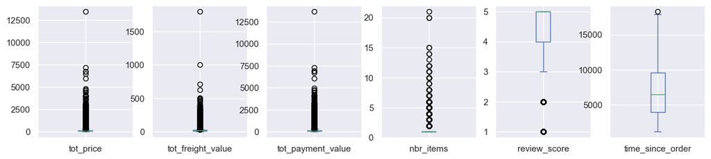

```python
columns_list = ['tot_price', 'tot_freight_value', 'tot_payment_value',
                'nbr_items', 'review_score', 'time_since_order']
orders_data[columns_list].plot(kind='box', subplots=True,
                               figsize=(15, 3), layout=(1, 6))
plt.show()
```

```python
columns_list = ['tot_price', 'tot_freight_value',
                'tot_payment_value', 'nbr_items']
Outliers_Limits(orders_data, columns_list, 1, 10)
print('After removing those outliers, we are left with this number of orders:',
      orders_data.shape[0])
```

```
Number of outliers to remove: 876
After removing those outliers, we are left with this number of orders: 95602
```

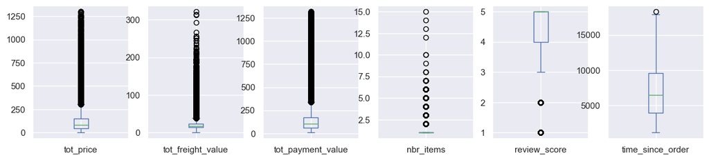

```python
columns_list = ['tot_price', 'tot_freight_value', 'tot_payment_value',
                'nbr_items', 'review_score', 'time_since_order']
orders_data[columns_list].plot(kind='box', subplots=True,
                               figsize=(15, 3), layout=(1, 6))
plt.show()
```

### C. Missing value treatment

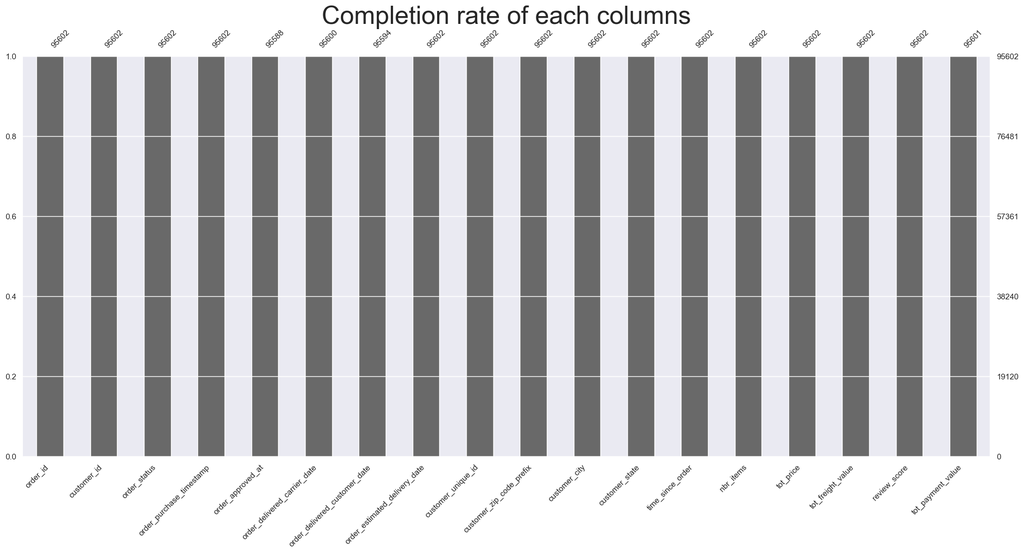

```python
msno.bar(orders_data, fontsize=11)
plt.title('Completion rate of each columns', fontsize=35)
plt.show()
```

#### a) Treatment of tot_price, tot_freight_value, and tot_payment_value

```python
display((orders_data[['tot_price', 'tot_freight_value',
                      'tot_payment_value']].notna())
        .groupby(['tot_price', 'tot_freight_value',
                  'tot_payment_value']).size())
```

```
tot_price  tot_freight_value  tot_payment_value
True       True               False                    1
                              True                 95601
dtype: int64
```

```python
orders_data[orders_data['tot_payment_value'].isna()]
```

|  | order_id | customer_id | order_status | order_purchase_timestamp | order_approved_at | order_delivered_carrier_date | order_delivered_customer_date | order_estimated_delivery_date | customer_unique_id | customer_zip_code_prefix | customer_city | customer_state | time_since_order | nbr_items | tot_price | tot_freight_value | review_score | tot_payment_value |
| --- | --- | --- | --- | --- | --- | --- | --- | --- | --- | --- | --- | --- | --- | --- | --- | --- | --- | --- |
| 30710 | bfbd0f9bdef84302105ad712db648a6c | 86dc2ffce2dfff336de2f386a786e574 | delivered | 2016-09-15 12:16:38 | 2016-09-15 12:16:38 | 2016-11-07 17:11:53 | 2016-11-09 07:47:38 | 2016-10-04 00:00:00 | 830d5b7aaa3b6f1e9ad63703bec97d23 | 14600 | sao joaquim da barra | SP | 18293.0 | 3.0 | 134.97 | 8.49 | 1 | NaN |

```python
cond = orders_data[orders_data['tot_payment_value'].isna()]
print('The number of orders with missing values in tot_payment_value',
      cond.shape[0])

orders_data.drop(cond.index, inplace=True)

print('After removing those rows, we are left with this number of orders:',
      orders_data.shape[0])
```

```
The number of orders with missing values in tot_payment_value 1
After removing those rows, we are left with this number of orders: 95601
```

```python
# Replacing the values in tot_payment_value by the sum of tot_price
# and tot_freight_value
orders_data.loc[orders_data.index,
                'tot_payment_value'] = (orders_data['tot_price']
                                        + orders_data['tot_freight_value'])
```

#### b) Treatment of order_approved_at, order_delivered_carrier_date, and order_delivered_customer_date

```python
display((orders_data[['order_approved_at', 'order_delivered_carrier_date',
                      'order_delivered_customer_date']].notna())
        .groupby(['order_approved_at', 'order_delivered_carrier_date',
                  'order_delivered_customer_date']).size())
```

```
order_approved_at  order_delivered_carrier_date  order_delivered_customer_date
False              True                          True                                14
True               False                         False                                1
                                                 True                                 1
                   True                          False                                7
                                                 True                             95578
dtype: int64
```

```python
orders_data[orders_data['order_delivered_customer_date'].isna()]\
           .groupby('order_status').nunique()['order_id']
```

```
order_status
delivered    8
Name: order_id, dtype: int64
```

We see that few orders are delivered but with missing value in order_delivered_customer_date.  
We will proceed and drop all the orders with missing values in order_delivered_customer_date.

```python
cond = orders_data[(orders_data['order_delivered_customer_date'].isna())]
print('The number of rows with missing values in nbr_items',
      cond.shape[0])
orders_data.drop(cond.index, inplace=True)
print('After removing those rows, we are left with this number of rows:',
      orders_data.shape[0])
```

```
The number of rows with missing values in nbr_items 8
After removing those rows, we are left with this number of rows: 95593
```

#### c) Final check for missing values

```python
df_description(orders_data)
```

|  | order_id | customer_id | order_status | order_purchase_timestamp | order_approved_at | order_delivered_carrier_date | order_delivered_customer_date | order_estimated_delivery_date | customer_unique_id | customer_zip_code_prefix | customer_city | customer_state | time_since_order | nbr_items | tot_price | tot_freight_value | review_score | tot_payment_value |
| --- | --- | --- | --- | --- | --- | --- | --- | --- | --- | --- | --- | --- | --- | --- | --- | --- | --- | --- |
| type | object | object | object | datetime64[ns] | object | object | object | object | object | int64 | object | object | float64 | float64 | float64 | float64 | int64 | float64 |
| number null | 0.0 | 0.0 | 0.0 | 0.0 | 14.0 | 1.0 | 0.0 | 0.0 | 0.0 | 0.0 | 0.0 | 0.0 | 0.0 | 0.0 | 0.0 | 0.0 | 0.0 | 0.0 |
| percentage null | 0.0 | 0.0 | 0.0 | 0.0 | 0.014645 | 0.001046 | 0.0 | 0.0 | 0.0 | 0.0 | 0.0 | 0.0 | 0.0 | 0.0 | 0.0 | 0.0 | 0.0 | 0.0 |
| count | 95593 | 95593 | 95593 | 95593 | 95579 | 95592 | 95593 | 95593 | 95593 | 95593.0 | 95593 | 95593 | 95593.0 | 95593.0 | 95593.0 | 95593.0 | 95593.0 | 95593.0 |
| unique | 95593 | 95593 | 1 | NaN | 87522 | 79422 | 94793 | 444 | 92508 | NaN | 4065 | 27 | NaN | NaN | NaN | NaN | NaN | NaN |
| top | e481f51cbdc54678b7cc49136f2d6af7 | 9ef432eb6251297304e76186b10a928d | delivered | NaN | 2018-02-27 04:31:10 | 2018-05-09 15:48:00 | 2016-10-27 17:32:07 | 2017-12-20 00:00:00 | 8d50f5eadf50201ccdcedfb9e2ac8455 | NaN | sao paulo | SP | NaN | NaN | NaN | NaN | NaN | NaN |
| freq | 1 | 1 | 95593 | NaN | 9 | 47 | 3 | 504 | 15 | NaN | 14970 | 40267 | NaN | NaN | NaN | NaN | NaN | NaN |
| mean | NaN | NaN | NaN | 2018-01-01 21:13:33.650560 | NaN | NaN | NaN | NaN | NaN | 35122.356658 | NaN | NaN | 6931.779607 | 1.1316 | 125.144627 | 21.903573 | 4.146653 | 147.0482 |
| min | NaN | NaN | NaN | 2016-10-03 09:44:50 | NaN | NaN | NaN | NaN | NaN | 1003.0 | NaN | NaN | 1178.0 | 1.0 | 0.85 | 0.0 | 1.0 | 9.59 |
| 25% | NaN | NaN | NaN | 2017-09-13 23:16:51 | NaN | NaN | NaN | NaN | NaN | 11310.0 | NaN | NaN | 3961.0 | 1.0 | 45.9 | 13.79 | 4.0 | 61.64 |
| 50% | NaN | NaN | NaN | 2018-01-20 17:57:51 | NaN | NaN | NaN | NaN | NaN | 24360.0 | NaN | NaN | 6479.0 | 1.0 | 85.0 | 17.09 | 5.0 | 104.28 |
| 75% | NaN | NaN | NaN | 2018-05-05 15:56:36 | NaN | NaN | NaN | NaN | NaN | 58900.0 | NaN | NaN | 9570.0 | 1.0 | 149.5 | 23.7 | 5.0 | 173.74 |
| max | NaN | NaN | NaN | 2018-08-29 15:00:37 | NaN | NaN | NaN | NaN | NaN | 99980.0 | NaN | NaN | 17863.0 | 15.0 | 1299.99 | 321.46 | 5.0 | 1319.32 |
| std | NaN | NaN | NaN | NaN | NaN | NaN | NaN | NaN | NaN | 29838.95029 | NaN | NaN | 3667.532043 | 0.481872 | 140.403256 | 16.449016 | 1.292408 | 147.846475 |

Few missing values still in order_approved_at and order_delivered_carrier_date  
which will not be treated since those columns are not so important for the clustering.

## 3. Feature Engineering

Features that will be created:

```python
# Converting all date columns to datetime type
date_columns = ['order_purchase_timestamp',
                'order_approved_at',
                'order_delivered_carrier_date',
                'order_delivered_customer_date',
                'order_estimated_delivery_date']
orders_data[date_columns] = orders_data[date_columns].apply(pd.to_datetime)

# Cretaing three columns delivery_time, estimated_vs_actual_delivery_date,
# and late_delivery that will be used later for the feature engineering
orders_data['delivery_time(h)'] = (orders_data['order_delivered_customer_date']
                                   - orders_data['order_purchase_timestamp'])\
                                  .astype('timedelta64[h]')
```

```python
# Column that will be used to count the number of times an order_id appeared
orders_data['dummy_col'] = 1

# Groupby the dataset according to order_id
cust_uniq_df = orders_data\
               .groupby('customer_unique_id')\
               .agg(nbr_orders=('dummy_col', 'sum'),
                    time_since_last_order_h=('time_since_order', 'min'),
                    sum_tot_payment_value=('tot_payment_value', 'sum'),
                    review_score=('review_score', 'mean'),
                    delivery_time_h=('delivery_time(h)', 'mean'))

# Creating order_id column
cust_uniq_df['customer_unique_id'] = cust_uniq_df.index

# Resetting the index of the created dataset
cust_uniq_df = cust_uniq_df.reset_index(drop=True)

cust_uniq_df.shape
```

```
(92508, 6)
```

```python
# Rounding mean_review_score
cust_uniq_df['review_score'] = cust_uniq_df['review_score'].round()

# Creating mean_payment_value column
cust_uniq_df['payment_value'] = (cust_uniq_df['sum_tot_payment_value']
                                 / cust_uniq_df['nbr_orders'])

# Dropping sum_tot_payment_value column
cust_uniq_df = cust_uniq_df.drop('sum_tot_payment_value',
                                 axis=1)

# Resetting the index of the dataset
cust_uniq_df = cust_uniq_df.reset_index(drop=True)

# Checking the dataset
print('Size of the cust_uniq_df:', cust_uniq_df.shape)
df_description(cust_uniq_df)
```

```
Size of the cust_uniq_df: (92508, 6)
```

|  | nbr_orders | time_since_last_order_h | review_score | delivery_time_h | customer_unique_id | payment_value |
| --- | --- | --- | --- | --- | --- | --- |
| type | int64 | float64 | float64 | float64 | object | float64 |
| number null | 0.0 | 0.0 | 0.0 | 0.0 | 0.0 | 0.0 |
| percentage null | 0.0 | 0.0 | 0.0 | 0.0 | 0.0 | 0.0 |
| count | 92508.0 | 92508.0 | 92508.0 | 92508.0 | 92508 | 92508.0 |
| unique | NaN | NaN | NaN | NaN | 92508 | NaN |
| top | NaN | NaN | NaN | NaN | 0000366f3b9a7992bf8c76cfdf3221e2 | NaN |
| freq | NaN | NaN | NaN | NaN | 1 | NaN |
| mean | 1.033348 | 6879.109526 | 4.143252 | 300.444941 | NaN | 147.324793 |
| std | 0.208516 | 3661.644806 | 1.288276 | 228.474951 | NaN | 147.652733 |
| min | 1.0 | 1178.0 | 1.0 | 12.0 | NaN | 9.59 |
| 25% | 1.0 | 3914.0 | 4.0 | 162.0 | NaN | 62.01 |
| 50% | 1.0 | 6426.0 | 5.0 | 245.0 | NaN | 104.72 |
| 75% | 1.0 | 9481.0 | 5.0 | 375.0 | NaN | 173.84 |
| max | 15.0 | 17856.0 | 5.0 | 5031.0 | NaN | 1319.32 |

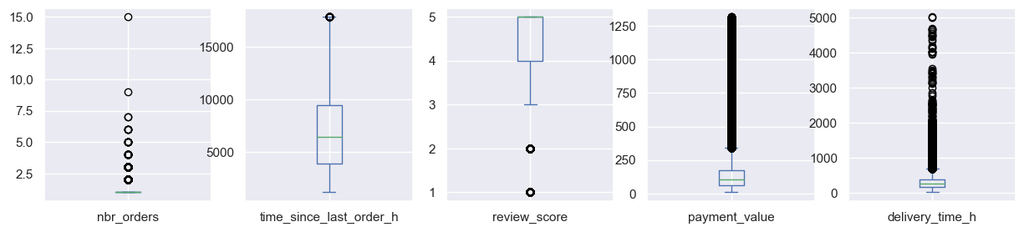

```python
columns_list = ['nbr_orders', 'time_since_last_order_h',
                'review_score', 'payment_value', 'delivery_time_h']
cust_uniq_df[columns_list].plot(kind='box', subplots=True,
                                figsize=(15, 3), layout=(1, 5))
plt.show()
```

Limiting the number of orders to 7 in cust_uniq_df.

```python
cond = cust_uniq_df[cust_uniq_df['nbr_orders'] > 7]
customers_unique_id_list = list(cond['customer_unique_id'])
print('The number of rows with high nbr_orders', cond.shape[0])
cust_uniq_df.drop(cond.index, inplace=True)
print('After removing those rows, we are left with {} in cust_uniq_df.'
      .format(cust_uniq_df.shape[0]))
```

```
The number of rows with high nbr_orders 2
After removing those rows, we are left with 92506 in cust_uniq_df.
```

Removing those customers_unique_id from orders_data dataframe

```python
for customer_unique_id in customers_unique_id_list:
    cond = orders_data[orders_data['customer_unique_id'] == customer_unique_id]
    print('The number of rows with high nbr_orders', cond.shape[0])
    orders_data.drop(cond.index, inplace=True)
print('After removing those rows, we are left with {} in orders_data.'
      .format(orders_data.shape[0]))
```

```
The number of rows with high nbr_orders 9
The number of rows with high nbr_orders 15
After removing those rows, we are left with 95569 in orders_data.
```

## 4. Analysis

### A. Univariate analysis

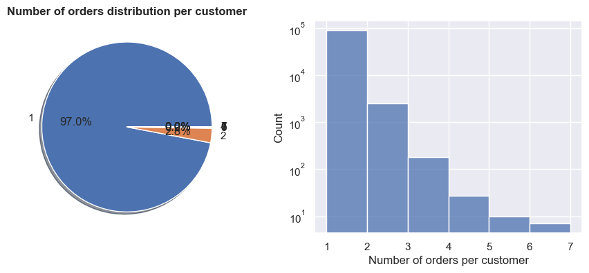

```python
fig, axes = plt.subplots(1, 2, figsize=(11, 4))
axes[0].pie(cust_uniq_df.groupby(by='nbr_orders').size(),
            labels=cust_uniq_df.groupby(by='nbr_orders').size().index,
            startangle=0,
            shadow=True,
            autopct='%1.1f%%')
axes[0].set_title('Number of orders distribution per customer',
                  fontsize=12, fontweight='bold')
sns.histplot(data=cust_uniq_df, x='nbr_orders',
             binwidth=1, ax=axes[1])
axes[1].set_xlabel('Number of orders per customer')
axes[1].set_yscale('log')
plt.show()
```

Most of customers made only one purchase while 3% of customers made multiple purchases.

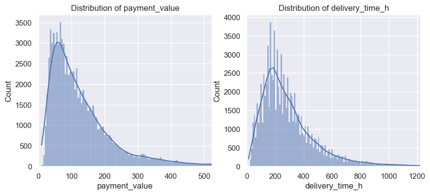

```python
columns_list = ['payment_value', 'delivery_time_h']
n_sub = len(columns_list)
n_col = 2
fig, axes = plt.subplots(int(round((0.49+n_sub/n_col), 0)),
                         n_col, figsize=(10, int(2*n_sub)))
i = 0
for col in columns_list:
    sns.histplot(data=cust_uniq_df, x=col,
                 kde=True, ax=axes[i])
    axes[i].set_title('Distribution of {}'.format(col))
    axes[i].set_xlim(0, cust_uniq_df[col].median()*5)
    i += 1
plt.show()
```

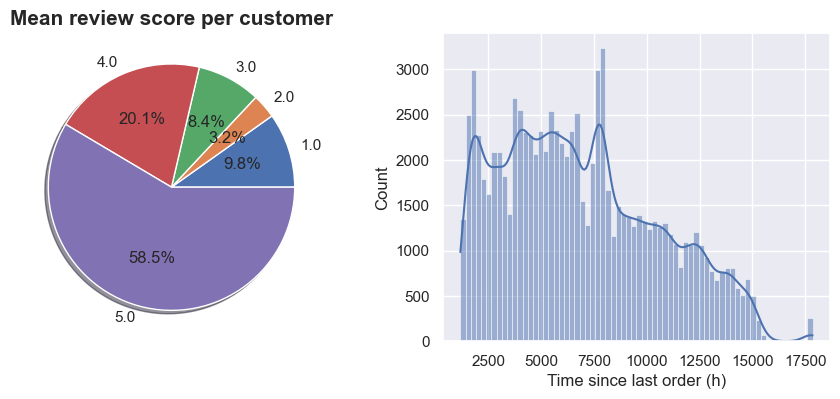

```python
fig, axes = plt.subplots(1, 2, figsize=(11, 4))
axes[0].pie(cust_uniq_df.groupby(by='review_score').size(),
            labels=cust_uniq_df.groupby(by='review_score').size().index,
            startangle=0,
            shadow=True,
            autopct='%1.1f%%')
axes[0].set_title('Mean review score per customer', fontsize=15,
                  fontweight='bold')
sns.histplot(data=cust_uniq_df, x='time_since_last_order_h',
             kde=True, ax=axes[1])
axes[1].set_xlabel('Time since last order (h)')
plt.show()
```

More than 78% of customers gave good review score (4 and 5)  
while around 13% of customers gave low review score (1 and 2).

### B. Bivariate analysis

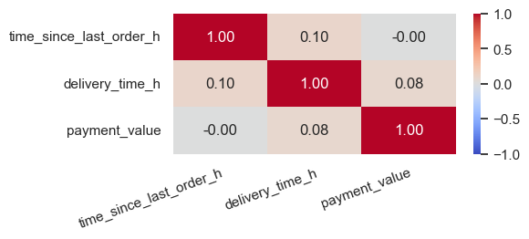

```python
columns_list = ['time_since_last_order_h', 'delivery_time_h', 'payment_value']
plt.figure(figsize=(5, 2))
sns.heatmap(cust_uniq_df[columns_list].corr(method='pearson'),
            vmin=-1, vmax=1, annot=True, cmap='coolwarm', fmt='0.2f')
plt.xticks(ha='right', rotation=20, rotation_mode='anchor')
plt.show()
```

No correlation between the numerical features.

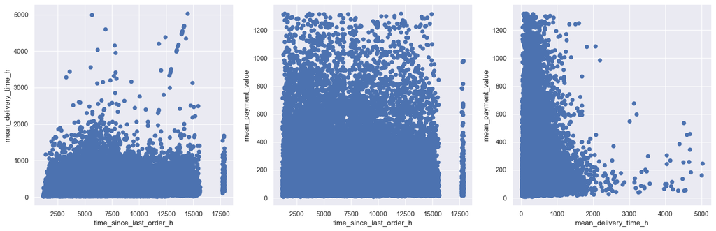

```python
fig, axes = plt.subplots(1, 3, figsize=(20, 6))
axes[0].plot(cust_uniq_df['time_since_last_order_h'],
             cust_uniq_df['delivery_time_h'], 'o')
axes[0].set_xlabel('time_since_last_order_h')
axes[0].set_ylabel('mean_delivery_time_h')
axes[1].plot(cust_uniq_df['time_since_last_order_h'],
             cust_uniq_df['payment_value'], 'o')
axes[1].set_xlabel('time_since_last_order_h')
axes[1].set_ylabel('mean_payment_value')
axes[2].plot(cust_uniq_df['delivery_time_h'],
             cust_uniq_df['payment_value'], 'o')
axes[2].set_xlabel('mean_delivery_time_h')
axes[2].set_ylabel('mean_payment_value')
plt.show()
```

```python
# Function that plot the distributions of some numerical columns
# for each categorcical columns
def distribution_of_num_for_each_categ(df, columns_list, cat_columns, n_col):
    n_sub = len(columns_list)
    for cat_column in cat_columns:
        fig, axes = plt.subplots(int(round((0.49+n_sub/n_col), 0)), n_col,
                                 figsize=(20, int(3.6*n_sub/n_col)))
        axes = np.array(axes)
        i = 0
        cat_list = df.groupby(by=cat_column).nunique()\
                     .sort_values(cat_column, ascending=True).head(10).index
        for ax in axes.reshape(-1):
            groupes = []
            for m in cat_list:
                groupes.append(df[df[cat_column] == m][columns_list[i]])
            ax.boxplot(groupes, labels=cat_list, showfliers=False,
                       vert=False, patch_artist=True, showmeans=True)
            ax.set_xlabel(format(columns_list[i]))
            if i % n_col == 0:
                ax.set_ylabel(format(cat_column))
            i += 1
        plt.show()
```

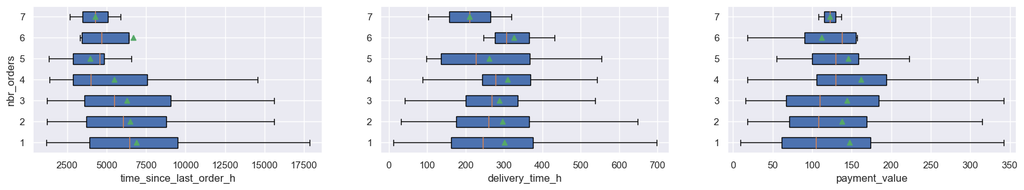

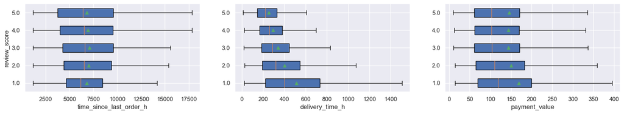

```python
# Plotting the distributions of some quantitative columns for each BuildingType
columns_list = ['time_since_last_order_h', 'delivery_time_h', 'payment_value']
cat_columns = ['nbr_orders', 'review_score']

distribution_of_num_for_each_categ(cust_uniq_df, columns_list,
                                   cat_columns, 3)
```

Observations:

- Customers who made multiple orders made order(s) recently.
- Customers who gave low review score had long delivery time.

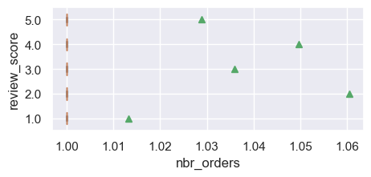

```python
plt.figure(figsize=(5, 2))

cat_list = cust_uniq_df.groupby(by='review_score').nunique()\
                       .sort_values('review_score', ascending=True)\
                       .head(10).index
groupes = []
for m in cat_list:
    groupes.append(cust_uniq_df[cust_uniq_df['review_score'] == m]
                   ['nbr_orders'])
plt.boxplot(groupes, labels=cat_list, showfliers=False,
            vert=False, patch_artist=True, showmeans=True)
plt.xlabel(format('nbr_orders'))
plt.ylabel(format('review_score'))

plt.show()
```

As shown before, customers who gave low review score had late delivery of their orders.

### C. Multivariate analysis

We will start standardizing the data, then we perform dimension reduction using t-SNE.  
The use of t-SNE is due to the non-linear relation between the features as seen in the analysis section.  
t-SNE will be performed on three sets of features:

- the RFM features
- the RFM features with the review score
- the RFM features with the review score and the delivery time

#### a) Standardize the data

```python
columns_list = ['time_since_last_order_h', 'delivery_time_h',
                'payment_value', 'nbr_orders', 'review_score']
# Centering and reducing the data by making all columns having the same power
# (same mean value and same standart deviation value).
cust_uniq_df = cust_uniq_df.reset_index(drop=True)
cust_uniq_df_norm = pd.DataFrame(StandardScaler()
                                 .fit_transform(cust_uniq_df[columns_list]))
cust_uniq_df_norm.columns = columns_list
cust_uniq_df_norm['customer_unique_id'] = cust_uniq_df['customer_unique_id']
df_description(cust_uniq_df_norm)
```

|  | time_since_last_order_h | delivery_time_h | payment_value | nbr_orders | review_score | customer_unique_id |
| --- | --- | --- | --- | --- | --- | --- |
| type | float64 | float64 | float64 | float64 | float64 | object |
| number null | 0.0 | 0.0 | 0.0 | 0.0 | 0.0 | 0.0 |
| percentage null | 0.0 | 0.0 | 0.0 | 0.0 | 0.0 | 0.0 |
| count | 92506.0 | 92506.0 | 92506.0 | 92506.0 | 92506.0 | 92506 |
| unique | NaN | NaN | NaN | NaN | NaN | 92506 |
| top | NaN | NaN | NaN | NaN | NaN | 0000366f3b9a7992bf8c76cfdf3221e2 |
| freq | NaN | NaN | NaN | NaN | NaN | 1 |
| mean | 0.0 | -0.0 | -0.0 | -0.0 | -0.0 | NaN |
| std | 1.000005 | 1.000005 | 1.000005 | 1.000005 | 1.000005 | NaN |
| min | -1.557012 | -1.262486 | -0.932834 | -0.164158 | -2.439897 | NaN |
| 25% | -0.809801 | -0.60596 | -0.577813 | -0.164158 | -0.1112 | NaN |
| 50% | -0.123766 | -0.242682 | -0.288554 | -0.164158 | 0.665033 | NaN |
| 75% | 0.710565 | 0.326308 | 0.17957 | -0.164158 | 0.665033 | NaN |
| max | 2.997805 | 20.70489 | 7.937476 | 29.582326 | 0.665033 | NaN |

#### b) Performing dimension reduction using t-SNE

##### i) RFM features

```python
tsne = TSNE(n_components=2, perplexity=50, n_iter=1000,
            init='pca', random_state=42, n_jobs=-1)
cols_RFM = ['nbr_orders', 'time_since_last_order_h', 'payment_value']
cust_uniq_df_RFM_tsne = tsne.fit_transform(cust_uniq_df_norm[cols_RFM])
cust_uniq_df_RFM_tsne = pd.DataFrame(cust_uniq_df_RFM_tsne,
                                     columns=['Dim_1_RFM_tsne',
                                              'Dim_2_RFM_tsne'])
```

```python
# Merging the TSNE results with the non scaled dataset
cust_uniq_df_tsne = pd.merge(cust_uniq_df,
                             cust_uniq_df_RFM_tsne,
                             left_index=True,
                             right_index=True,
                             how='inner')
cust_uniq_df_tsne.head()

# Merging the TSNE results with the scaled dataset
cust_uniq_df_norm_tsne = pd.merge(cust_uniq_df_norm,
                                  cust_uniq_df_RFM_tsne,
                                  left_index=True,
                                  right_index=True,
                                  how='inner')
cust_uniq_df_norm_tsne.head()
```

|  | time_since_last_order_h | delivery_time_h | payment_value | nbr_orders | review_score | customer_unique_id | Dim_1_RFM_tsne | Dim_2_RFM_tsne |
| --- | --- | --- | --- | --- | --- | --- | --- | --- |
| 0 | -0.828372 | -0.645351 | -0.036748 | -0.164158 | 0.665033 | 0000366f3b9a7992bf8c76cfdf3221e2 | 38.302284 | 47.814457 |
| 1 | -0.808709 | -0.973615 | -0.813636 | -0.164158 | -0.111200 | 0000b849f77a49e4a4ce2b2a4ca5be3f | 94.735985 | -37.067242 |
| 2 | 1.961105 | 1.385504 | -0.413848 | -0.164158 | -0.887432 | 0000f46a3911fa3c0805444483337064 | -122.556427 | -19.140877 |
| 3 | 0.545610 | 0.785877 | -0.702361 | -0.164158 | -0.111200 | 0000f6ccb0745a6a4b88665a16c9f078 | -24.516495 | -97.956093 |
| 4 | 0.329313 | 0.063697 | 0.335679 | -0.164158 | 0.665033 | 0004aac84e0df4da2b147fca70cf8255 | -40.615044 | 25.281872 |

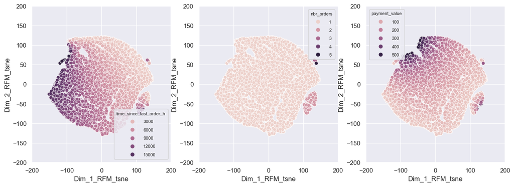

```python
fig, axes = plt.subplots(1, 3, figsize=(15, 5))
colomns_list = ['time_since_last_order_h', 'nbr_orders', 'payment_value']
i = 0
for col in colomns_list:
    data = cust_uniq_df_tsne[cust_uniq_df_tsne[col]
                             <= cust_uniq_df_tsne[col].median()*5]
    sns.scatterplot(data=data,
                    x='Dim_1_RFM_tsne',
                    y='Dim_2_RFM_tsne',
                    hue=col,
                    ax=axes[i])
    axes[i].set_xlim(-200, 200)
    axes[i].set_ylim(-200, 200)
    plt.setp(axes[i].get_legend().get_texts(), fontsize='8')  # for legend text
    plt.setp(axes[i].get_legend().get_title(), fontsize='8')  # for legend titl
    i += 1
plt.show()
```

Observations:

- For time since last order feature, customers that made purchase recently have higher dimension 1  
  and 2 value in t-SNE than the customers that made purchase long time ago.
- For nbr of orders feature, customers that made multiple orders have high  
  dimension 1 value in t-SNE than customers that made only one order.
- For payment value feature, customers that made high value purchase have higher  
  dimension 2 value in t-SNE than the customers that made low value purchase.

##### ii) RFM + review score features

```python
tsne = TSNE(n_components=2, perplexity=50, n_iter=1000,
            init='pca', random_state=42, n_jobs=-1)
cols_RFM_RS = ['nbr_orders', 'time_since_last_order_h',
               'payment_value', 'review_score']
cust_uniq_df_RFM_RS_tsne = tsne.fit_transform(cust_uniq_df_norm[cols_RFM_RS])
cust_uniq_df_RFM_RS_tsne = pd.DataFrame(cust_uniq_df_RFM_RS_tsne,
                                        columns=['Dim_1_RFM_RS_tsne',
                                                 'Dim_2_RFM_RS_tsne'])
```

```python
# Merging the TSNE results with the non scaled dataset
cust_uniq_df_tsne = pd.merge(cust_uniq_df_tsne,
                             cust_uniq_df_RFM_RS_tsne,
                             left_index=True,
                             right_index=True,
                             how='inner')
cust_uniq_df_tsne.head()

# Merging the TSNE results with the scaled dataset
cust_uniq_df_norm_tsne = pd.merge(cust_uniq_df_norm_tsne,
                                  cust_uniq_df_RFM_RS_tsne,
                                  left_index=True,
                                  right_index=True,
                                  how='inner')
cust_uniq_df_norm_tsne.head()
```

|  | time_since_last_order_h | delivery_time_h | payment_value | nbr_orders | review_score | customer_unique_id | Dim_1_RFM_tsne | Dim_2_RFM_tsne | Dim_1_RFM_RS_tsne | Dim_2_RFM_RS_tsne |
| --- | --- | --- | --- | --- | --- | --- | --- | --- | --- | --- |
| 0 | -0.828372 | -0.645351 | -0.036748 | -0.164158 | 0.665033 | 0000366f3b9a7992bf8c76cfdf3221e2 | 38.302284 | 47.814457 | 53.231316 | 28.470566 |
| 1 | -0.808709 | -0.973615 | -0.813636 | -0.164158 | -0.111200 | 0000b849f77a49e4a4ce2b2a4ca5be3f | 94.735985 | -37.067242 | 15.645178 | 30.573647 |
| 2 | 1.961105 | 1.385504 | -0.413848 | -0.164158 | -0.887432 | 0000f46a3911fa3c0805444483337064 | -122.556427 | -19.140877 | -107.702881 | -55.528736 |
| 3 | 0.545610 | 0.785877 | -0.702361 | -0.164158 | -0.111200 | 0000f6ccb0745a6a4b88665a16c9f078 | -24.516495 | -97.956093 | -35.535019 | -57.575523 |
| 4 | 0.329313 | 0.063697 | 0.335679 | -0.164158 | 0.665033 | 0004aac84e0df4da2b147fca70cf8255 | -40.615044 | 25.281872 | 19.037970 | -35.633228 |

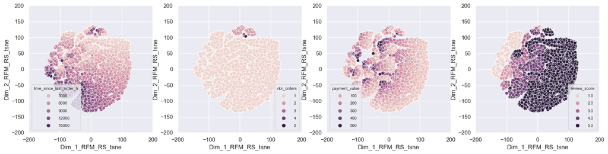

```python
fig, axes = plt.subplots(1, 4, figsize=(20, 4.5))
colomns_list = ['time_since_last_order_h', 'nbr_orders',
                'payment_value', 'review_score']
i = 0
for col in colomns_list:
    data = cust_uniq_df_tsne[cust_uniq_df_tsne[col]
                             <= cust_uniq_df_tsne[col].median()*5]
    sns.scatterplot(data=data,
                    x='Dim_1_RFM_RS_tsne',
                    y='Dim_2_RFM_RS_tsne',
                    hue=col,
                    ax=axes[i])
    axes[i].set_xlim(-200, 200)
    axes[i].set_ylim(-200, 200)
    plt.setp(axes[i].get_legend().get_texts(), fontsize='8')  # for legend text
    plt.setp(axes[i].get_legend().get_title(), fontsize='8')  # for legend titl
    i += 1
plt.show()
```

Observations:

- For time since last order feature, customers that made purchase recently have higher dimension 1  
  and 2 value in t-SNE than the customers that made purchase long time ago.
- For nbr of orders feature, customers that made multiple orders have high  
  dimension 2 value in t-SNE than customers that made only one order.
- For payment value feature, it's hard to assign regions.
- For review score feature, customers that gave good review score have higher  
  dimension 1 value in t-SNE than the customers that gave low review score.

##### iii) RFM + review score + delivery time features

```python
tsne = TSNE(n_components=2, perplexity=50, n_iter=1000,
            init='pca', random_state=42, n_jobs=-1)
cols_RFM_RS_DT = ['nbr_orders', 'time_since_last_order_h',
                  'payment_value', 'review_score',
                  'delivery_time_h']
cust_uniq_df_RFM_RS_DT_tsne = tsne.fit_transform(cust_uniq_df_norm[cols_RFM_RS_DT])
cust_uniq_df_RFM_RS_DT_tsne = pd.DataFrame(cust_uniq_df_RFM_RS_DT_tsne,
                                           columns=['Dim_1_RFM_RS_DT_tsne',
                                                    'Dim_2_RFM_RS_DT_tsne'])
```

```python
# Merging the TSNE results with the non scaled dataset
cust_uniq_df_tsne = pd.merge(cust_uniq_df_tsne,
                             cust_uniq_df_RFM_RS_DT_tsne,
                             left_index=True,
                             right_index=True,
                             how='inner')
cust_uniq_df_tsne.head()

# Merging the TSNE results with the scaled dataset
cust_uniq_df_norm_tsne = pd.merge(cust_uniq_df_norm_tsne,
                                  cust_uniq_df_RFM_RS_DT_tsne,
                                  left_index=True,
                                  right_index=True,
                                  how='inner')
cust_uniq_df_norm_tsne.head()
```

|  | time_since_last_order_h | delivery_time_h | payment_value | nbr_orders | review_score | customer_unique_id | Dim_1_RFM_tsne | Dim_2_RFM_tsne | Dim_1_RFM_RS_tsne | Dim_2_RFM_RS_tsne | Dim_1_RFM_RS_DT_tsne | Dim_2_RFM_RS_DT_tsne |
| --- | --- | --- | --- | --- | --- | --- | --- | --- | --- | --- | --- | --- |
| 0 | -0.828372 | -0.645351 | -0.036748 | -0.164158 | 0.665033 | 0000366f3b9a7992bf8c76cfdf3221e2 | 38.302284 | 47.814457 | 53.231316 | 28.470566 | -83.783745 | 29.099510 |
| 1 | -0.808709 | -0.973615 | -0.813636 | -0.164158 | -0.111200 | 0000b849f77a49e4a4ce2b2a4ca5be3f | 94.735985 | -37.067242 | 15.645178 | 30.573647 | 0.099724 | 69.799248 |
| 2 | 1.961105 | 1.385504 | -0.413848 | -0.164158 | -0.887432 | 0000f46a3911fa3c0805444483337064 | -122.556427 | -19.140877 | -107.702881 | -55.528736 | 75.253540 | -29.539938 |
| 3 | 0.545610 | 0.785877 | -0.702361 | -0.164158 | -0.111200 | 0000f6ccb0745a6a4b88665a16c9f078 | -24.516495 | -97.956093 | -35.535019 | -57.575523 | 39.546257 | -31.594627 |
| 4 | 0.329313 | 0.063697 | 0.335679 | -0.164158 | 0.665033 | 0004aac84e0df4da2b147fca70cf8255 | -40.615044 | 25.281872 | 19.037970 | -35.633228 | -49.541283 | -29.783381 |

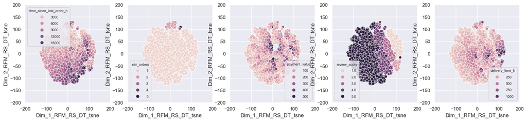

```python
fig, axes = plt.subplots(1, 5, figsize=(20, 4))
colomns_list = ['time_since_last_order_h', 'nbr_orders',
                'payment_value', 'review_score',
                'delivery_time_h']
i = 0
for col in colomns_list:
    data = cust_uniq_df_tsne[cust_uniq_df_tsne[col]
                             <= cust_uniq_df_tsne[col].median()*5]
    sns.scatterplot(data=data,
                    x='Dim_1_RFM_RS_DT_tsne',
                    y='Dim_2_RFM_RS_DT_tsne',
                    hue=col,
                    ax=axes[i])
    axes[i].set_xlim(-200, 200)
    axes[i].set_ylim(-200, 200)
    plt.setp(axes[i].get_legend().get_texts(), fontsize='8')  # for legend text
    plt.setp(axes[i].get_legend().get_title(), fontsize='8')  # for legend titl
    i += 1
plt.show()
```

Observations:

- For time since last order feature, customers that made purchase recently have lower dimension 1  
  and higher dimension 2 values in t-SNE than the customers that made purchase long time ago.
- For nbr of orders feature, customers that made multiple orders have high  
  dimension 2 value in t-SNE than customers that made only one order.
- For payment value feature, it's hard to assign regions.
- For review score feature, customers that gave good review score have lower  
  dimension 1 value in t-SNE than the customers that gave low review score.
- For delivery time, customers that had long delivery time had higher  
  dimension 1 value in t-SNE.

## 5. Extracting the datasets

```python
df_description(cust_uniq_df_norm_tsne)
```

|  | time_since_last_order_h | delivery_time_h | payment_value | nbr_orders | review_score | customer_unique_id | Dim_1_RFM_tsne | Dim_2_RFM_tsne | Dim_1_RFM_RS_tsne | Dim_2_RFM_RS_tsne | Dim_1_RFM_RS_DT_tsne | Dim_2_RFM_RS_DT_tsne |
| --- | --- | --- | --- | --- | --- | --- | --- | --- | --- | --- | --- | --- |
| type | float64 | float64 | float64 | float64 | float64 | object | float32 | float32 | float32 | float32 | float32 | float32 |
| number null | 0.0 | 0.0 | 0.0 | 0.0 | 0.0 | 0.0 | 0.0 | 0.0 | 0.0 | 0.0 | 0.0 | 0.0 |
| percentage null | 0.0 | 0.0 | 0.0 | 0.0 | 0.0 | 0.0 | 0.0 | 0.0 | 0.0 | 0.0 | 0.0 | 0.0 |
| count | 92506.0 | 92506.0 | 92506.0 | 92506.0 | 92506.0 | 92506 | 92506.0 | 92506.0 | 92506.0 | 92506.0 | 92506.0 | 92506.0 |
| unique | NaN | NaN | NaN | NaN | NaN | 92506 | NaN | NaN | NaN | NaN | NaN | NaN |
| top | NaN | NaN | NaN | NaN | NaN | 0000366f3b9a7992bf8c76cfdf3221e2 | NaN | NaN | NaN | NaN | NaN | NaN |
| freq | NaN | NaN | NaN | NaN | NaN | 1 | NaN | NaN | NaN | NaN | NaN | NaN |
| mean | 0.0 | -0.0 | -0.0 | -0.0 | -0.0 | NaN | -0.165195 | 0.241055 | 0.692512 | -0.610111 | -0.003926 | -0.275092 |
| std | 1.000005 | 1.000005 | 1.000005 | 1.000005 | 1.000005 | NaN | 68.680786 | 60.676144 | 65.989899 | 63.22731 | 60.935413 | 58.874203 |
| min | -1.557012 | -1.262486 | -0.932834 | -0.164158 | -2.439897 | NaN | -150.689102 | -129.645874 | -145.925293 | -132.357849 | -128.223129 | -125.142067 |
| 25% | -0.809801 | -0.60596 | -0.577813 | -0.164158 | -0.1112 | NaN | -54.580124 | -46.142888 | -50.868428 | -50.248682 | -48.717608 | -46.105665 |
| 50% | -0.123766 | -0.242682 | -0.288554 | -0.164158 | 0.665033 | NaN | -0.070813 | -0.603778 | 1.157957 | 0.431901 | -1.889924 | 1.126859 |
| 75% | 0.710565 | 0.326308 | 0.17957 | -0.164158 | 0.665033 | NaN | 52.628413 | 47.424028 | 52.362757 | 49.077914 | 46.20974 | 45.881613 |
| max | 2.997805 | 20.70489 | 7.937476 | 29.582326 | 0.665033 | NaN | 145.105957 | 120.249741 | 127.797981 | 134.975876 | 128.720795 | 130.71431 |

```python
orders_data = orders_data.reset_index(drop=True)
orders_data.to_csv('orders_data.csv', sep='\t', index=False)
cust_uniq_df_tsne = cust_uniq_df_tsne.reset_index(drop=True)
cust_uniq_df_tsne.to_csv('cust_uniq_df_tsne.csv',
                         sep='\t', index=False)
cust_uniq_df_norm_tsne = cust_uniq_df_norm_tsne.reset_index(drop=True)
cust_uniq_df_norm_tsne.to_csv('cust_uniq_df_norm_tsne.csv',
                              sep='\t', index=False)
```